# Project: Investigate a Dataset - TMDB Movies

## Exploratory Data Analysis

### How have movie release trends changed over the years?

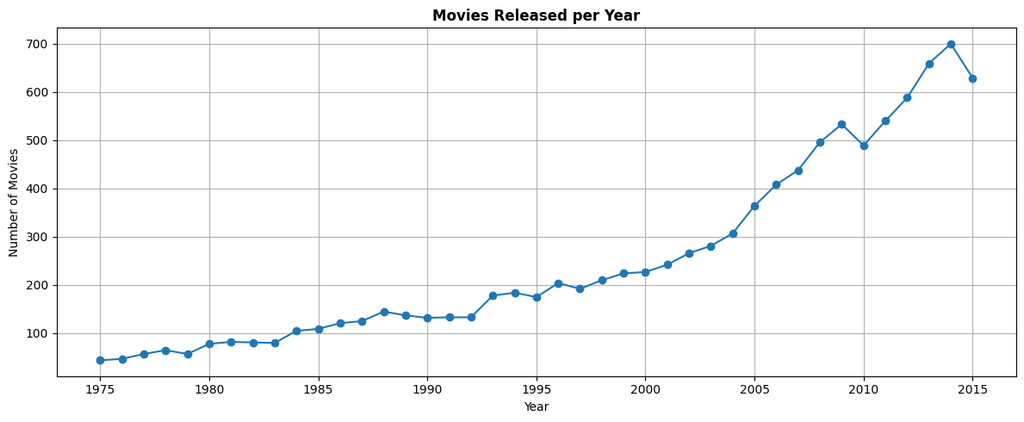

|  | release_year | movies_released | avg_budget | avg_revenue | median_revenue |
| --- | --- | --- | --- | --- | --- |
| 0 | 1975 | 44 | 4.019929e+06 | 6.383266e+07 | 27476252.0 |
| 1 | 1976 | 47 | 7.185294e+06 | 5.006285e+07 | 34578246.5 |
| 2 | 1977 | 57 | 5.984444e+06 | 9.085763e+07 | 30374571.0 |
| 3 | 1978 | 65 | 7.740630e+06 | 5.707415e+07 | 28494887.5 |
| 4 | 1979 | 57 | 1.061725e+07 | 6.239981e+07 | 39946780.0 |
| 5 | 1980 | 78 | 1.169355e+07 | 4.535032e+07 | 22471595.0 |
| 6 | 1981 | 82 | 8.898995e+06 | 4.436516e+07 | 27839500.0 |
| 7 | 1982 | 81 | 1.250843e+07 | 6.146110e+07 | 27121707.0 |
| 8 | 1983 | 80 | 1.297769e+07 | 4.437556e+07 | 20338309.0 |
| 9 | 1984 | 105 | 1.350393e+07 | 4.972688e+07 | 28078073.0 |
| 10 | 1985 | 109 | 1.361310e+07 | 4.292198e+07 | 20518905.0 |
| 11 | 1986 | 121 | 1.174223e+07 | 3.951024e+07 | 16713741.0 |

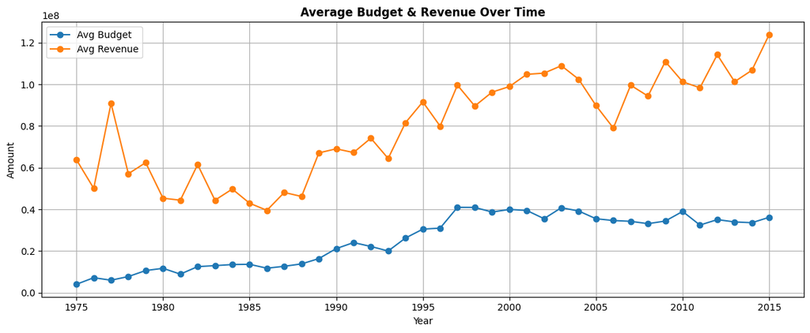

```python
# Movies released per year (count)
movies_per_year = df.groupby('release_year').size().rename('movie_count').sort_index()
movies_per_year = movies_per_year.dropna()

# Plot: movies per year (line)
plt.figure(figsize=(12,5))
plt.plot(movies_per_year.index, movies_per_year.values, marker='o')
format_plot("Movies Released per Year", "Year", "Number of Movies")
plt.show()

# Yearly averages of budget and revenue (for years with non-null values)
yearly_stats = df.groupby('release_year').agg(
    movies_released = ('id' if 'id' in df.columns else 'original_title', 'count'),
    avg_budget = ('budget', 'mean'),
    avg_revenue = ('revenue', 'mean'),
    median_revenue = ('revenue', 'median')
).reset_index().sort_values('release_year')

display(yearly_stats.head(12))

# Plot avg_budget and avg_revenue (line)
plt.figure(figsize=(12,5))
plt.plot(yearly_stats['release_year'], yearly_stats['avg_budget'], label='Avg Budget', marker='o')
plt.plot(yearly_stats['release_year'], yearly_stats['avg_revenue'], label='Avg Revenue', marker='o')
plt.legend()
format_plot("Average Budget & Revenue Over Time", "Year", "Amount")
plt.show()
```

**Observations**

- The number of movies released per year shows clear growth in later decades; check plotted peaks for exact years.
- Average budgets and revenues trend upward over time; however, average revenue is noisy due to missing values and outliers (blockbusters).
- Because `revenue` and `budget` are not inflation adjusted, increases over time may reflect inflation and market growth; adjust for CPI when needed for causal claims.

### What genres produce the highest ratings?

We measure "ratings" using `vote_average` (TMDb average rating).  
We will compute average and median `vote_average` per genre, and require a minimum count threshold to reduce noise.

|  | genre | movie_count | avg_rating | median_rating |
| --- | --- | --- | --- | --- |
| 5 | Documentary | 520 | 6.908462 | 7.00 |
| 12 | Music | 408 | 6.480392 | 6.50 |
| 10 | History | 334 | 6.410479 | 6.50 |
| 2 | Animation | 699 | 6.403147 | 6.40 |
| 18 | War | 270 | 6.297778 | 6.40 |
| 6 | Drama | 4761 | 6.165301 | 6.20 |
| 4 | Crime | 1355 | 6.124059 | 6.10 |
| 19 | Western | 165 | 6.083030 | 6.10 |
| 14 | Romance | 1712 | 6.042874 | 6.10 |
| 7 | Family | 1231 | 5.997563 | 6.00 |
| 9 | Foreign | 188 | 5.981383 | 6.05 |
| 13 | Mystery | 810 | 5.946790 | 6.00 |
| 1 | Adventure | 1471 | 5.940585 | 6.00 |
| 3 | Comedy | 3793 | 5.905167 | 5.90 |
| 8 | Fantasy | 916 | 5.863537 | 5.90 |
| 16 | TV Movie | 167 | 5.788024 | 5.90 |
| 0 | Action | 2385 | 5.787421 | 5.90 |
| 17 | Thriller | 2908 | 5.750413 | 5.80 |
| 15 | Science Fiction | 1230 | 5.665041 | 5.80 |
| 11 | Horror | 1637 | 5.337447 | 5.40 |

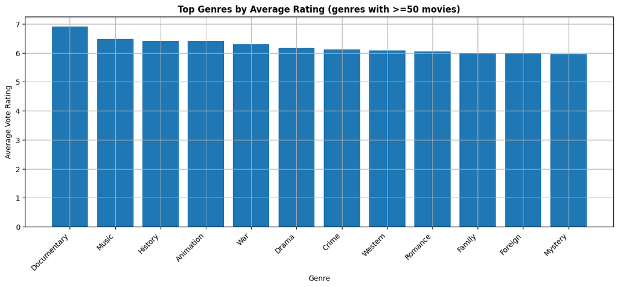

```python
# Ensure vote_average numeric
df = clean_numeric(df, 'vote_average')

# Use the exploded df_genres (one row per genre)
df_genres = df_genres.copy()
df_genres['vote_average'] = pd.to_numeric(df_genres['vote_average'], errors='coerce')

# Aggregate by genre
genre_ratings = df_genres.groupby('genre').agg(
    movie_count = ('id' if 'id' in df_genres.columns else 'original_title', 'count'),
    avg_rating = ('vote_average', 'mean'),
    median_rating = ('vote_average', 'median')
).reset_index().sort_values('avg_rating', ascending=False)

# Add a filter to focus on genres with at least 50 movies to avoid tiny-genre noise
genre_ratings['movie_count'] = genre_ratings['movie_count'].fillna(0).astype(int)
genre_ratings_filtered = genre_ratings[genre_ratings['movie_count'] >= 50].sort_values('avg_rating', ascending=False)

display(genre_ratings_filtered)

# Plot: average rating by genre (top 12 by avg_rating)
top_genre_ratings = genre_ratings_filtered.sort_values('avg_rating', ascending=False).head(12)
plt.figure(figsize=(12,5))
plt.bar(top_genre_ratings['genre'], top_genre_ratings['avg_rating'])
format_plot("Top Genres by Average Rating (genres with >=50 movies)", "Genre", "Average Vote Rating")
plt.xticks(rotation=45, ha='right')
plt.show()
```

**Observations**

- Genres with the highest average `vote_average` (after filtering to >= 50 movies) appear at the top of the displayed table and bar chart.
- Using a movie count threshold helps reduce volatility due to small-sample genres.
- Consider also looking at median ratings and rating distributions (boxplots) to understand outliers.